# GDD distribution maps in Newfoundland and Canada

To get a sense of the *effective growing degree days* distribution in both Newfoundland and Canada, I grabbed the temperature data in all stations available and calculated GDD values in a specific year. Because the completeness of temperature data in different years are different, after experimentation, I decided to use the 2015 data for Newfoundland and 2016 data for Canada to give some decent results.

## 1. GDD Map for Newfoundland

```python
import pandas as pd
import numpy as np
import cartopy.crs as ccrs
import sys
import os
import matplotlib.pyplot as plt

from cumgdd import cumgdd
from download_data_func import download_data_func

tbase = 10
tupper = 30
year = 2015

# Get station list from station inventory which exists from the previous download step
station_inventory = "station_inventory.csv"
inventory_df = pd.read_csv(station_inventory, usecols=(0,1,3,6,7,15,16),index_col=0,skiprows=3,sep=',')
inventory_df = inventory_df.dropna()

# Get the list of NEWFOUNDLAND stations with valid data for a specific year
NL_inventory_df = inventory_df[(inventory_df['Province']=='NEWFOUNDLAND') & (inventory_df['DLY Last Year']>=year) & (inventory_df["DLY First Year"]<=year)]

NL_stations = NL_inventory_df['Station ID'].tolist()
cumulative_gdd_list = []

# Download temparature data files for all cities in the list
for station in NL_stations:
    download_data_func(station, year)
    infile = 'Data/' + str(station) + '_' + str(year) + '.csv'
    cumulative_gdd_list.append(cumgdd(infile, tbase, tupper))

# Add a column of cumulative gdd values
NL_inventory_df.insert(loc=4, column='Cumulative GDD', value=cumulative_gdd_list)
NL_inventory_df.to_csv('inventory_df.csv')
```

### GDD contour plot for Newfoundland in 2015

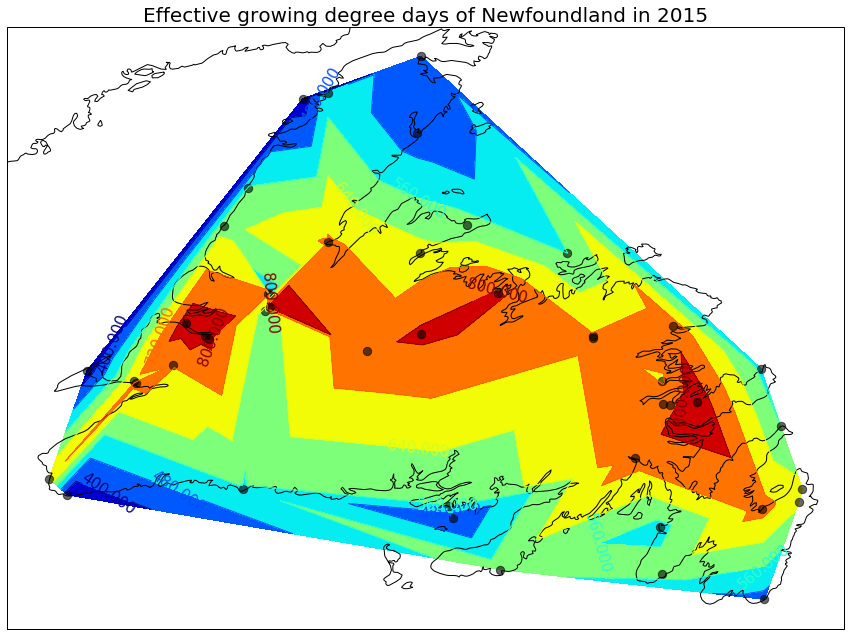

```python
import matplotlib.pyplot as plt
from scipy.interpolate import griddata
%matplotlib inline

fig = plt.figure(figsize=(15,20))
ax = plt.axes(projection=ccrs.PlateCarree())

NL_inventory_df = NL_inventory_df.dropna(subset=["Cumulative GDD"])

# Choose latitude > 51.6
NL_inventory_df = NL_inventory_df[NL_inventory_df["Latitude (Decimal Degrees)"]<51.6]
lats = np.array(NL_inventory_df['Latitude (Decimal Degrees)'].tolist())
lons = np.array(NL_inventory_df['Longitude (Decimal Degrees)'].tolist())
cgdd = np.array(NL_inventory_df["Cumulative GDD"].tolist())

ax.coastlines('10m')
c = ax.tricontour(lons, lats, cgdd)
ax.clabel(c, inline=1, fontsize=15)
ax.tricontourf(lons, lats, cgdd)
ax.scatter(lons, lats, marker='o', color='k', s=70, transform=ccrs.PlateCarree(),alpha=0.6)
plt.title("Effective growing degree days of Newfoundland in 2015", fontsize=20)
```

From the contour plot of GDD values, we see that GDD values in central Newfoundland is higher than other areas and is around 800. The black dots in the figure are station samples. While the lowest GDD value in Newfoundland can be only around 400. This could be lower than the true value, the reason is that the temperature data in some stations are not complete, and I just dropped those missing data. I did not choose to interpolate those missing data because there are many stations which missed a lot of data, it would be greatly overestimating the gdd values if the interpolation scheme is not appropriate. All of these are because the data is not complete, but this plot shows the general pattern of GDD distribution in Newfoundland.

## 2. GDD Map for all Canada

For the GDD distribution in all Canada, I showed the result with both scatter plot and contour plot, they described the GDD pattern of Canada in a complementary way.

```python
import pandas as pd
import numpy as np
import cartopy.crs as ccrs
import sys
import os
import matplotlib.pyplot as plt
#import pdb

from cumgdd import cumgdd
from download_data_func import download_data_func

tbase = 10
tupper = 30
year = 2016

# Get station list from station inventory which exists from the previous download step
station_inventory = "station_inventory.csv"
inventory_df = pd.read_csv(station_inventory, usecols=(0,1,3,6,7,15,16),index_col=0,skiprows=3,sep=',')
inventory_df = inventory_df.dropna()

# Get the list of NEWFOUNDLAND stations with valid data for a specific year
inventory_df = inventory_df[(inventory_df['DLY Last Year']>=year) & (inventory_df["DLY First Year"]<=year)]

all_stations = inventory_df['Station ID'].tolist()
cumulative_gdd_list = []

# Download temparature data files for all cities in the list
for station in all_stations:
#    pdb.set_trace()
    download_data_func(station, year)
    infile = 'Data/' + str(station) + '_' + str(year) + '.csv'
    cumulative_gdd_list.append(cumgdd(infile, tbase, tupper))

# Add a column of cumulative gdd values
inventory_df.insert(loc=4, column='Cumulative GDD', value=cumulative_gdd_list)
inventory_df.dropna(subset=["Cumulative GDD"], inplace=True)
inventory_df.to_csv('inventory_df_CAN.csv')
```

### GDD scatter plot for all Canada

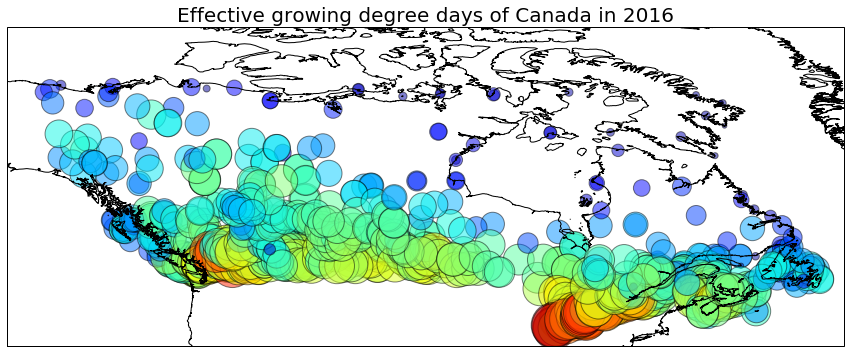

```python
import matplotlib.pyplot as plt
%matplotlib inline

fig = plt.figure(figsize=(15,20))
ax = plt.axes(projection=ccrs.PlateCarree())

inventory_df = inventory_df[inventory_df["Latitude (Decimal Degrees)"]<70]
lats = inventory_df['Latitude (Decimal Degrees)'].values
lons = inventory_df['Longitude (Decimal Degrees)'].values
cgdd = np.array(inventory_df["Cumulative GDD"].tolist())

ax.coastlines('10m')
ax.scatter(lons, lats, marker='o', c=cgdd, s=cgdd, transform=ccrs.PlateCarree(), alpha=0.5)
ax.set_extent([-145,-50,40,70])
plt.title("Effective growing degree days of Canada in 2016", fontsize=20)
```

As can be seen from the above figure, the darker colored and bigger circles implies larger GDD values. GDD values in south Canada are much more larger than in north, this is absolutely resonable. In addition, we see two red areas, one is somewhere in Vancouver, the other is somewhere near Toronto. To see more clearly, we need the help of contour plot in the following figure.

### GDD contour plot for all Canada

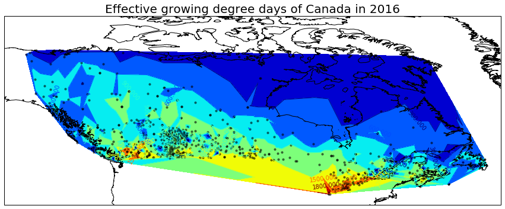

```python
import matplotlib.pyplot as plt
%matplotlib inline

fig = plt.figure(figsize=(15,20))
ax = plt.axes(projection=ccrs.PlateCarree())

inventory_df = inventory_df[inventory_df["Latitude (Decimal Degrees)"]<70]
lats = inventory_df['Latitude (Decimal Degrees)'].values
lons = inventory_df['Longitude (Decimal Degrees)'].values
cgdd = np.array(inventory_df["Cumulative GDD"].tolist())

ax.coastlines('10m')
c = ax.tricontour(lons, lats, cgdd)
ax.clabel(c, inline=1, fontsize=10)
ax.tricontourf(lons, lats, cgdd)
ax.scatter(lons, lats, marker='o', color='k', s=10, transform=ccrs.PlateCarree(), alpha=0.5)
ax.set_extent([-145,-50,40,70])
plt.title("Effective growing degree days of Canada in 2016", fontsize=20)
```

The contour plot show the same pattern with the scatter plot, where those black dots are sampled stations. In addition, we see that the biggest GDD values in the red area is around 1800, the yellow area is around 1500, and so on.